# Gabarito lista 2

Cristiano de Carvalho Santos

# Questão 1

Escolha 3 bancos de dados (que estão disponíveis no R em data()). Salve estes bancos em arquivos ’‘.txt’‘,’‘csv’’ e ‘’xls’’ (cada banco em um formato distinto). Importe estes dados novmente para o R, atribuindo-os aos objetos Dados1, Dados2 e Dados3, com as funções adequadas.

```r
# Exportação dos bancos de dados
write.table(Nile, file = "Nile.txt", row.names = FALSE, col.names = FALSE)
write.table(Orange, file = "Orange.csv", row.names = FALSE)
write_xlsx(InsectSprays , "InsectSprays.xlsx")
```

Uma obervação relevante: pode-ser ser usada também o pacote xlsx para gravar os dados, mas pode ser que haja problemas na instalação e execução do pacote. Uma alternativa é o pacote writexl para gravar os dados. Procure no help a documetação do pacote writexl e informações sobre a função write_xlsx.

```r
# Importação dos bancos de dados
dados1 = read.table("Nile.txt", header = FALSE, sep = " ")
dados2 = read.csv("Orange.csv", fill = TRUE, sep = " ")
dados3 = read_excel("InsectSprays.xlsx", sheet = 1)
```

# Questão 2

Faça uma análise descritiva das variáveis do banco de dados . Para carregar o banco de dados use o comando: data(ChickWeight).

Existem muitas alternativas para fazer as descritivas. Algumas solucoes estao abaixo:

```r
##Lendo o banco de dados ChickWeight:
data(ChickWeight)

attach(ChickWeight)
```

Analisando o banco de dados todo:

```r
#Vendo as primeiras observações do banco:
head(ChickWeight)
```

```
##   weight Time Chick Diet
## 1     42    0     1    1
## 2     51    2     1    1
## 3     59    4     1    1
## 4     64    6     1    1
## 5     76    8     1    1
## 6     93   10     1    1
```

```r
#Classe das variaveis:
sapply(ChickWeight, class)
```

```
## $weight
## [1] "numeric"
##
## $Time
## [1] "numeric"
##
## $Chick
## [1] "ordered" "factor"
##
## $Diet
## [1] "factor"
```

Medidas resumo para o banco:

```r
summary(ChickWeight)
```

```
##      weight           Time           Chick     Diet
##  Min.   : 35.0   Min.   : 0.00   13     : 12   1:220
##  1st Qu.: 63.0   1st Qu.: 4.00   9      : 12   2:120
##  Median :103.0   Median :10.00   20     : 12   3:120
##  Mean   :121.8   Mean   :10.72   10     : 12   4:118
##  3rd Qu.:163.8   3rd Qu.:16.00   17     : 12
##  Max.   :373.0   Max.   :21.00   19     : 12
##                                  (Other):506
```

Medias resumo para as variáveis qualitativas:

```r
#tabela de frequencia:
tabela1 <- table(Diet)
head(tabela1)
```

```
## Diet
##   1   2   3   4
## 220 120 120 118
```

```r
tabela2 <- table(Chick)
head(tabela2)
```

```
## Chick
## 18 16 15 13  9 20
##  2  7  8 12 12 12
```

```r
tabela3 <- table(ChickWeight[,c(3,4)])
head(tabela3)
```

```
##      Diet
## Chick  1  2  3  4
##    18  2  0  0  0
##    16  7  0  0  0
##    15  8  0  0  0
##    13 12  0  0  0
##    9  12  0  0  0
##    20 12  0  0  0
```

```r
#Tabela de proporções
prop1<-prop.table(tabela1)
head(round(prop1,2))
```

```
## Diet
##    1    2    3    4
## 0.38 0.21 0.21 0.20
```

```r
prop2 <- prop.table(tabela2)
head(round(prop2,2))
```

```
## Chick
##   18   16   15   13    9   20
## 0.00 0.01 0.01 0.02 0.02 0.02
```

```r
prop3 <- prop.table(tabela3)
head(round(prop3,2))
```

```
##      Diet
## Chick    1    2    3    4
##    18 0.00 0.00 0.00 0.00
##    16 0.01 0.00 0.00 0.00
##    15 0.01 0.00 0.00 0.00
##    13 0.02 0.00 0.00 0.00
##    9  0.02 0.00 0.00 0.00
##    20 0.02 0.00 0.00 0.00
```

Analise grafica para as variaveis qualitativas:

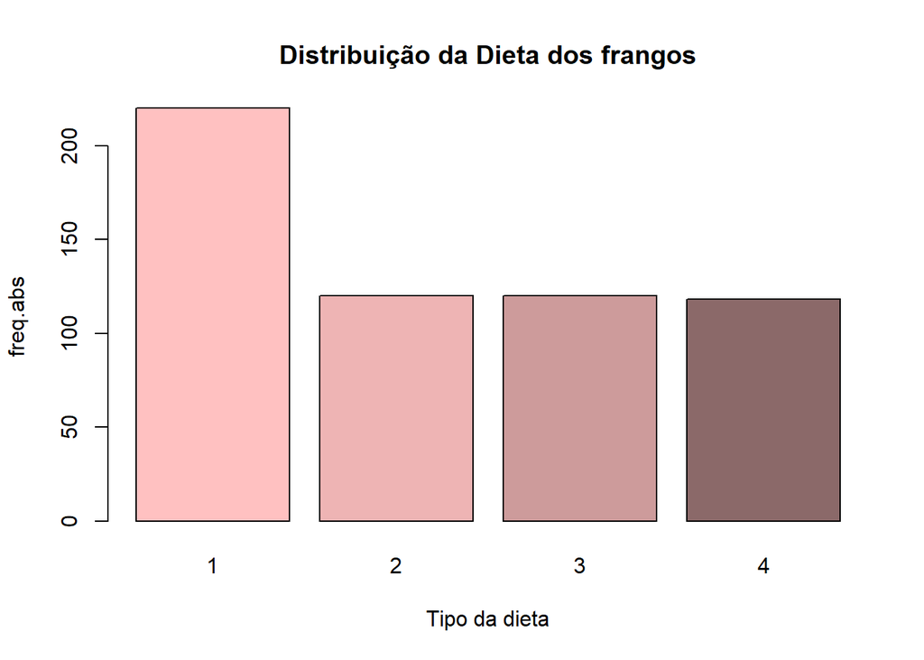

```r
#Gráfico de barras:
barplot(tabela1, main="Distribuição da Dieta dos frangos", ylab='freq.abs',
        xlab='Tipo da dieta', col=c('rosybrown1','rosybrown2','rosybrown3','rosybrown4'))
```

```r
#Para o tipo de frango, como são muitos niveis da variavel, fica dificil a
#visualização do grafico de barras
```

Para as variáveis quantitativas:

Medidas resumo:

```r
#Peso estratificado em cada nível da variavel Diet:
by(ChickWeight[,-4],Diet, summary)
```

```
## Diet: 1
##      weight            Time           Chick
##  Min.   : 35.00   Min.   : 0.00   13     : 12
##  1st Qu.: 57.75   1st Qu.: 4.00   9      : 12
##  Median : 88.00   Median :10.00   20     : 12
##  Mean   :102.65   Mean   :10.48   10     : 12
##  3rd Qu.:136.50   3rd Qu.:16.00   17     : 12
##  Max.   :305.00   Max.   :21.00   19     : 12
##                                   (Other):148
## ------------------------------------------------------------
## Diet: 2
##      weight           Time           Chick
##  Min.   : 39.0   Min.   : 0.00   24     :12
##  1st Qu.: 65.5   1st Qu.: 5.50   30     :12
##  Median :104.5   Median :11.00   22     :12
##  Mean   :122.6   Mean   :10.92   23     :12
##  3rd Qu.:163.0   3rd Qu.:16.50   27     :12
##  Max.   :331.0   Max.   :21.00   28     :12
##                                  (Other):48
## ------------------------------------------------------------
## Diet: 3
##      weight           Time           Chick
##  Min.   : 39.0   Min.   : 0.00   33     :12
##  1st Qu.: 67.5   1st Qu.: 5.50   37     :12
##  Median :125.5   Median :11.00   36     :12
##  Mean   :142.9   Mean   :10.92   31     :12
##  3rd Qu.:198.8   3rd Qu.:16.50   39     :12
##  Max.   :373.0   Max.   :21.00   38     :12
##                                  (Other):48
## ------------------------------------------------------------
## Diet: 4
##      weight            Time           Chick
##  Min.   : 39.00   Min.   : 0.00   45     :12
##  1st Qu.: 71.25   1st Qu.: 4.50   43     :12
##  Median :129.50   Median :10.00   41     :12
##  Mean   :135.26   Mean   :10.75   47     :12
##  3rd Qu.:184.75   3rd Qu.:16.00   49     :12
##  Max.   :322.00   Max.   :21.00   46     :12
##                                   (Other):46
```

```r
#Peso estratificado em cada nível da variável Chick:
by(ChickWeight[,-3],Chick, summary)
```

```
## Chick: 18
##      weight        Time     Diet
##  Min.   :35   Min.   :0.0   1:2
##  1st Qu.:36   1st Qu.:0.5   2:0
##  Median :37   Median :1.0   3:0
##  Mean   :37   Mean   :1.0   4:0
##  3rd Qu.:38   3rd Qu.:1.5
##  Max.   :39   Max.   :2.0
## ------------------------------------------------------------
## Chick: 16
##      weight           Time    Diet
##  Min.   :41.00   Min.   : 0   1:7
##  1st Qu.:47.00   1st Qu.: 3   2:0
##  Median :51.00   Median : 6   3:0
##  Mean   :49.71   Mean   : 6   4:0
##  3rd Qu.:52.50   3rd Qu.: 9
##  Max.   :57.00   Max.   :12
## ------------------------------------------------------------
## Chick: 15
##      weight           Time      Diet
##  Min.   :41.00   Min.   : 0.0   1:8
##  1st Qu.:54.25   1st Qu.: 3.5   2:0
##  Median :65.50   Median : 7.0   3:0
##  Mean   :60.12   Mean   : 7.0   4:0
##  3rd Qu.:68.00   3rd Qu.:10.5
##  Max.   :68.00   Max.   :14.0
## ------------------------------------------------------------
## Chick: 13
##      weight           Time       Diet
##  Min.   :41.00   Min.   : 0.00   1:12
##  1st Qu.:58.25   1st Qu.: 5.50   2: 0
##  Median :68.50   Median :11.00   3: 0
##  Mean   :67.83   Mean   :10.92   4: 0
##  3rd Qu.:73.50   3rd Qu.:16.50
##  Max.   :96.00   Max.   :21.00
## ------------------------------------------------------------
## Chick: 9
##      weight            Time       Diet
##  Min.   : 42.00   Min.   : 0.00   1:12
##  1st Qu.: 65.75   1st Qu.: 5.50   2: 0
```

[output cut: 394 more lines]

```
##  Min.   : 42.00   Min.   : 0.00   1: 0
##  1st Qu.: 78.75   1st Qu.: 5.50   2: 0
##  Median :143.00   Median :11.00   3: 0
##  Mean   :149.08   Mean   :10.92   4:12
##  3rd Qu.:211.50   3rd Qu.:16.50
##  Max.   :281.00   Max.   :21.00
## ------------------------------------------------------------
## Chick: 48
##      weight           Time       Diet
##  Min.   : 39.0   Min.   : 0.00   1: 0
##  1st Qu.: 75.5   1st Qu.: 5.50   2: 0
##  Median :139.5   Median :11.00   3: 0
##  Mean   :157.7   Mean   :10.92   4:12
##  3rd Qu.:231.8   3rd Qu.:16.50
##  Max.   :322.0   Max.   :21.00
```

```r
#Medidas de variabilidade:
var(weight)
```

```
## [1] 5051.223
```

```r
sd(weight)
```

```
## [1] 71.07196
```

```r
sd(weight)/mean(weight) #coeficiente de variacao
```

```
## [1] 0.5834258
```

```r
var(Time)
```

```
## [1] 45.67597
```

```r
sd(Time)
```

```
## [1] 6.7584
```

```r
sd(Time) / mean(Time) #coeficiente de variacao
```

```
## [1] 0.6305658
```

```r
#Fazendo uma função:
variabilidade <- function(x){
  tabela <-  c(sd(x),var(x), sd(x)/mean(x))
  names(tabela) = c("Desvio Padrao","Variancia", 'Coeficiente de variacao')
  return(tabela)
}

variabilidade(ChickWeight[,1])
```

```
##           Desvio Padrao               Variancia Coeficiente de variacao
##              71.0719596            5051.2234413               0.5834258
```

```r
variabilidade(ChickWeight[,2])
```

```
##           Desvio Padrao               Variancia Coeficiente de variacao
##               6.7583997              45.6759668               0.6305658
```

```r
#quantis:
quantile(weight, probs = c(0.10, 0.25, 0.50, 0.75, 0.90))
```

```
##    10%    25%    50%    75%    90%
##  47.70  63.00 103.00 163.75 223.60
```

```r
quantile(Time, probs = c(0.10, 0.25, 0.50, 0.75, 0.90))
```

```
## 10% 25% 50% 75% 90%
##   2   4  10  16  20
```

Analise gráfica das variaveis quantitativas:

Para a variavel Weight

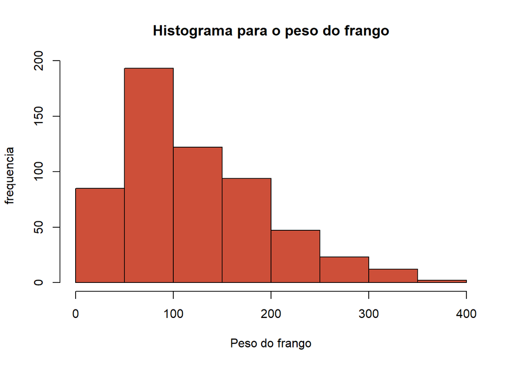

```r
#Graficos para a variavel peso:
hist(weight, main="Histograma para o peso do frango",
     xlab="Peso do frango", ylab="frequencia", col='tomato3') #histograma com frequencia absoluta
```

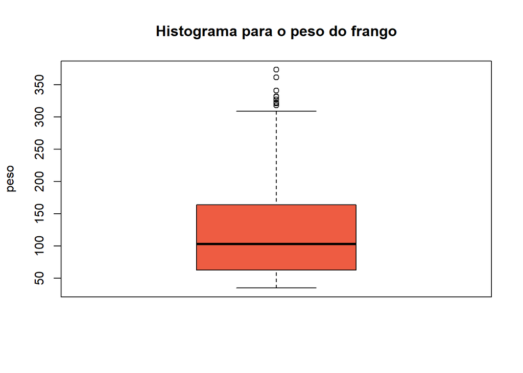

```r
boxplot(weight, main="Histograma para o peso do frango", ylab="peso", col='tomato2') #Boxplot da variavel peso
```

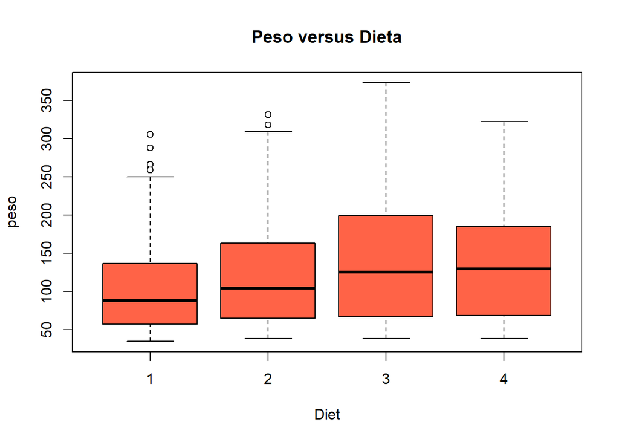

```r
boxplot(weight~Diet, main="Peso versus Dieta",ylab="peso", col='tomato1') #Boxplot Peso versus Dieta
```

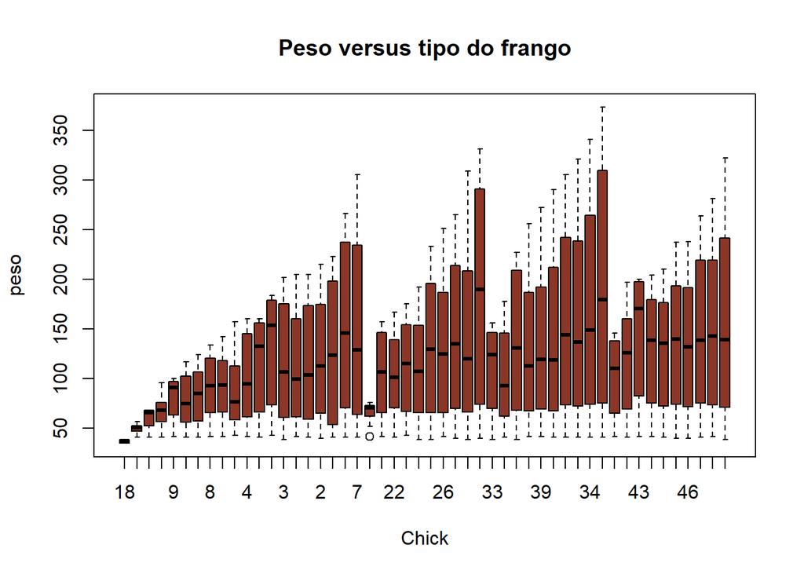

```r
boxplot(weight~Chick, main="Peso versus tipo do frango", ylab="peso", col='tomato4') #Boxplot Peso versus Dieta
```

Para a variavel time:

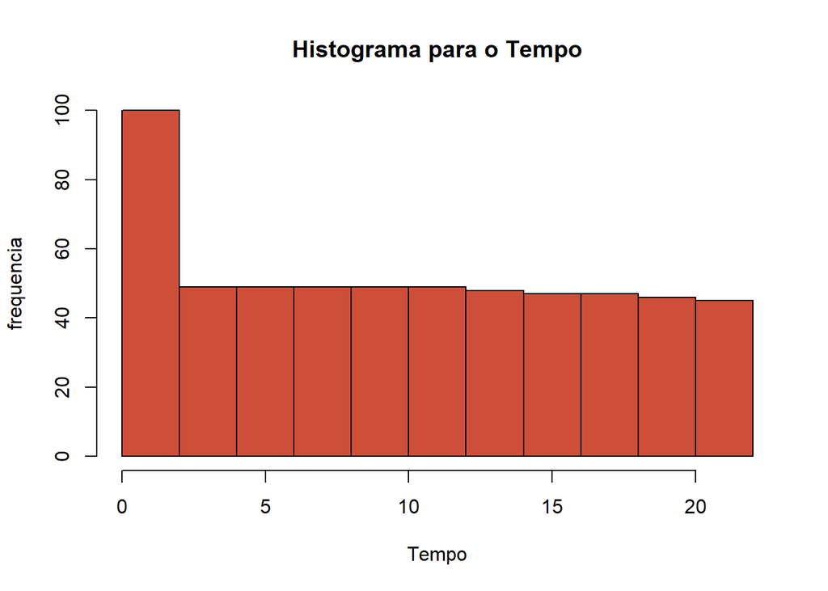

```r
#Graficos para a variavel tempo:
hist(Time, main="Histograma para o Tempo",
     xlab="Tempo", ylab="frequencia", col='tomato3') #histograma com frequencia absoluta
```

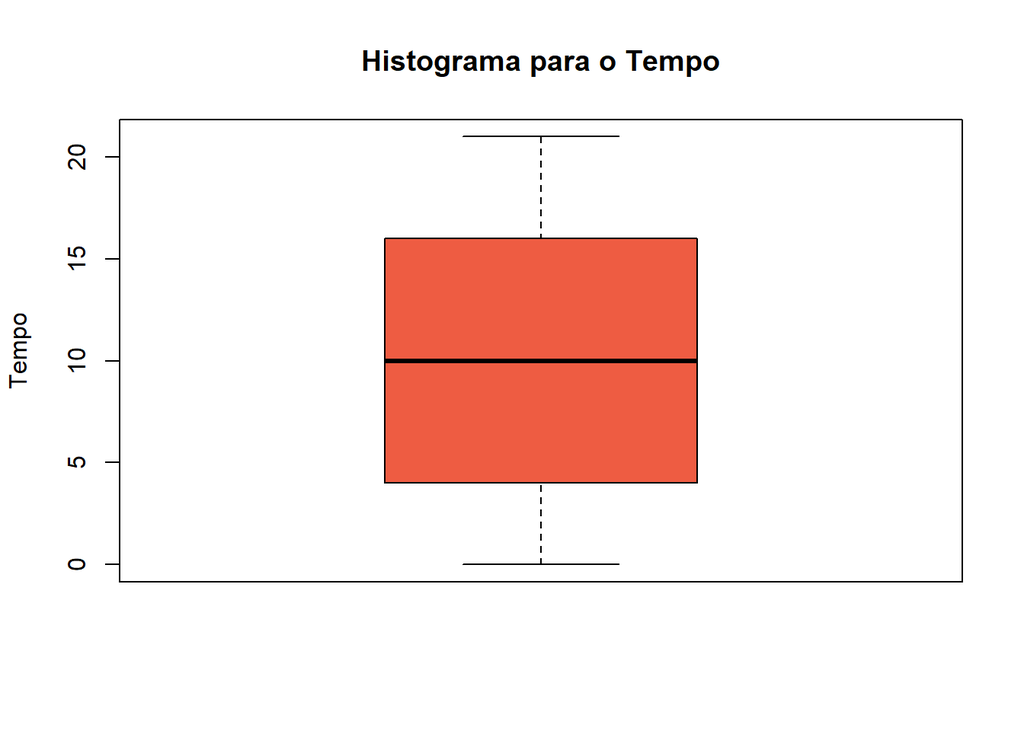

```r
boxplot(Time, main="Histograma para o Tempo", ylab="Tempo", col='tomato2') #Boxplot da variavel peso
```

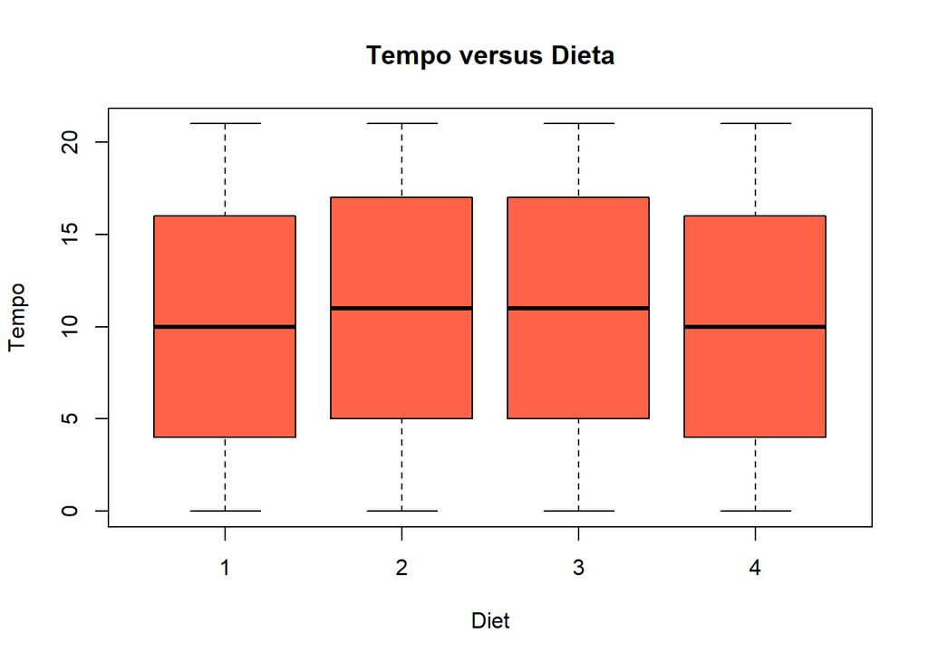

```r
boxplot(Time~Diet, main="Tempo versus Dieta",ylab="Tempo", col='tomato1') #Boxplot Peso versus Dieta
```

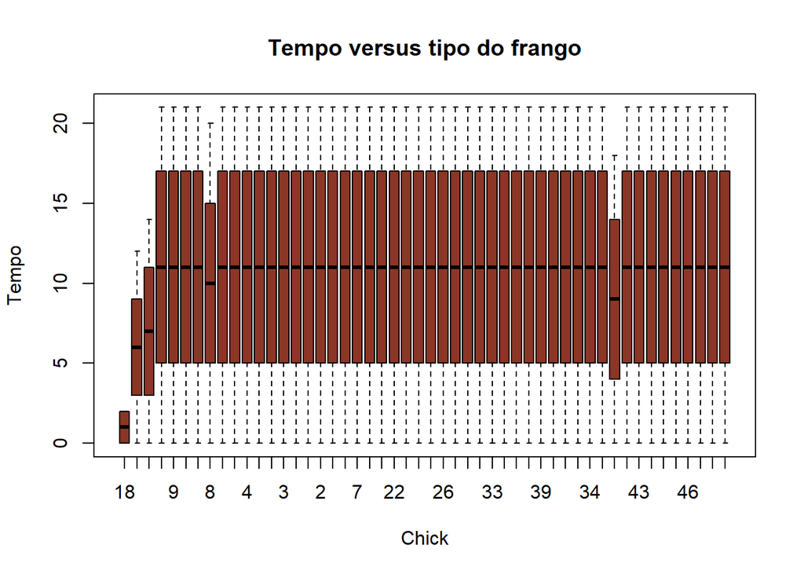

```r
boxplot(Time~Chick, main="Tempo versus tipo do frango", ylab="Tempo", col='tomato4') #Boxplot Peso versus Dieta
```

```r
detach(ChickWeight)
```

# Questão 3

Construa uma função para calcular média, quartis, variância, máximo e mínimo para a variável “wt” do banco de dados e retorne os resultados em uma tabela contendo os nomes de cada medida. Use o comando data(mtcars) para carregar o banco de dados.

```r
data(mtcars)

descritivas = function(x){
  tab = c(mean(x),quantile(x,probs=c(0.25,0.50,0.75)),sd(x),var(x))
  names(tab) = c("Media","Q1","Q2","Q3","Dp","Var")
  return(tab)
}
descritivas(mtcars$wt)
```

```
##     Media        Q1        Q2        Q3        Dp       Var
## 3.2172500 2.5812500 3.3250000 3.6100000 0.9784574 0.9573790
```

# Questão 4

Utilize a função layout para colocar 3 gráficos (histograma, boxplot, diagrama de pontos) de diferentes tamanhos em uma única janela gráfica (Acesse $https://www.statmethods.net/advgraphs/layout.html$). Use o banco de dados e o comando data(swiss) para carregar o banco de dados.

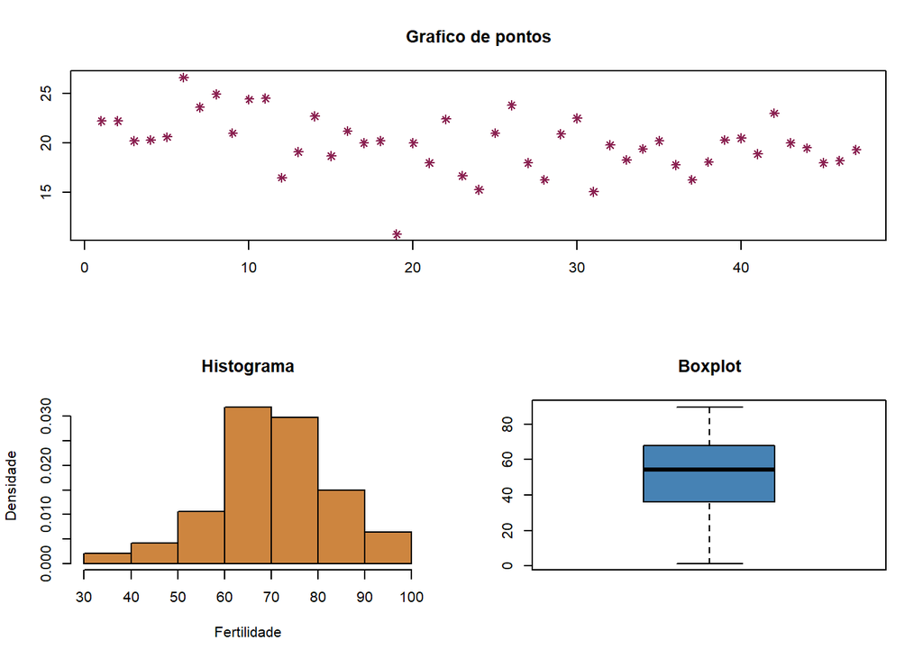

```r
data("swiss")
attach(swiss)

layout(matrix(c(1,1,1,1,1,1,2,2,2,3,3,3), 2, 6, byrow = TRUE))
plot(Infant.Mortality,main="Grafico de pontos",xlab = '',ylab = '',col="violetred4",pch=8)
hist(Fertility, main="Histograma",xlab = 'Fertilidade',ylab = 'Densidade',freq=F,col="tan3")
boxplot(Agriculture,main="Boxplot",freq=F,col="steelblue")
```

```r
detach(swiss)
```

# Questão 5

Pesquise na internet como fazer um gráfico de frequência acumulada.

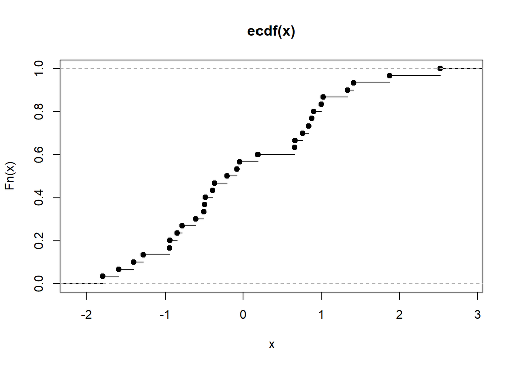

```r
x = rnorm(30) ## gerando uma amostra da Normal
fda =  ecdf(x) ## calculando frequencia acumulada
plot(fda)
```

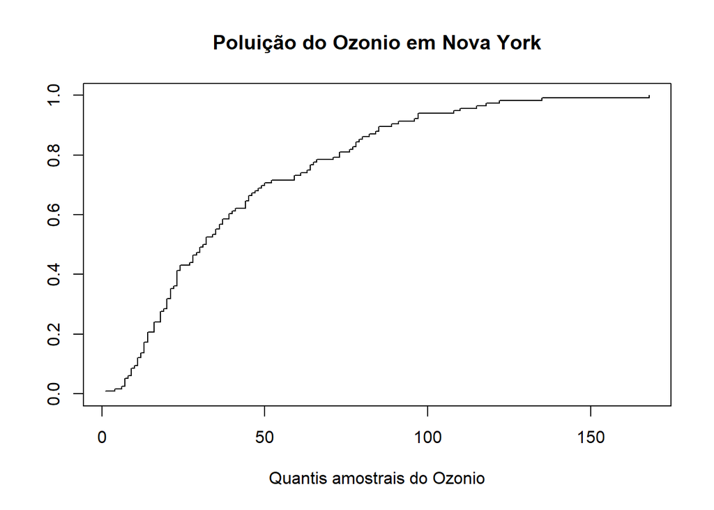

```r
## Outra forma
ozone = airquality$Ozone
ozone.ordered = sort(ozone)
n = length(ozone.ordered)
plot(ozone.ordered, (1:n)/n, type = 's', ylim = c(0, 1),
xlab = 'Quantis amostrais do Ozonio',
ylab = '', main = 'Poluição do Ozonio em Nova York')
```

# Questão 6

Carregue o conjunto de dados UScrime com o comando data(UScrime). Examine a sua documentação com help(UScrime) para obter mais informações sobre cada variável e responda as perguntas a seguir.

a - Qual o número médio das despesas policiais em 1960 e em 1959? Em qual ano teve a maior despesa média?

```r
data("UScrime")
?UScrime #Para obter informacoes sobre o banco de dados
```

```
## starting httpd help server ... done
```

```r
head(UScrime) #primeiras linhas do banco de dados
```

```
##     M So  Ed Po1 Po2  LF  M.F Pop  NW  U1 U2 GDP Ineq     Prob    Time    y
## 1 151  1  91  58  56 510  950  33 301 108 41 394  261 0.084602 26.2011  791
## 2 143  0 113 103  95 583 1012  13 102  96 36 557  194 0.029599 25.2999 1635
## 3 142  1  89  45  44 533  969  18 219  94 33 318  250 0.083401 24.3006  578
## 4 136  0 121 149 141 577  994 157  80 102 39 673  167 0.015801 29.9012 1969
## 5 141  0 121 109 101 591  985  18  30  91 20 578  174 0.041399 21.2998 1234
## 6 121  0 110 118 115 547  964  25  44  84 29 689  126 0.034201 20.9995  682
```

```r
#Primeira forma de obter o numero medio:
mean(UScrime[4]) #Para as despesas em 1960
```

```
## [1] NA
```

```r
mean(UScrime[5]) #Para as despesas em 1960
```

```
## [1] NA
```

```r
#Segunda forma de obter o numero medio:
summary(UScrime[c(4,5)])[4,]
```

```
##                Po1                Po2
##  "Mean   : 85.0  " "Mean   : 80.23  "
```

```r
#Terceira forma de obter o numero medio:
colMeans(UScrime[c(4,5)])
```

```
##      Po1      Po2
## 85.00000 80.23404
```

```r
#Quarta forma de obter o numero medio:
apply(UScrime[c(4,5)], 2, mean)
```

```
##      Po1      Po2
## 85.00000 80.23404
```

b - Encontre a mediana e quartis para as despesas policiais em 1959 e 1960.

```r
summary(UScrime[c(4,5)])[c(2,3,5),]
```

```
##       Po1             Po2
##  1st Qu.: 62.5   1st Qu.: 58.50
##  Median : 78.0   Median : 73.00
##  3rd Qu.:104.5   3rd Qu.: 97.00
```

c - Encontre o número máximo e mínimo para a taxa de desemprego entre homens com 14-24 anos.

```r
range(UScrime[10])
```

```
## [1]  70 142
```

```r
# outra forma
min(UScrime[10])
```

```
## [1] 70
```

```r
max(UScrime[10])
```

```
## [1] 142
```

d - Faça um gráfico adequado para o tempo medio cumpridos nas prisões estaduais (Time).

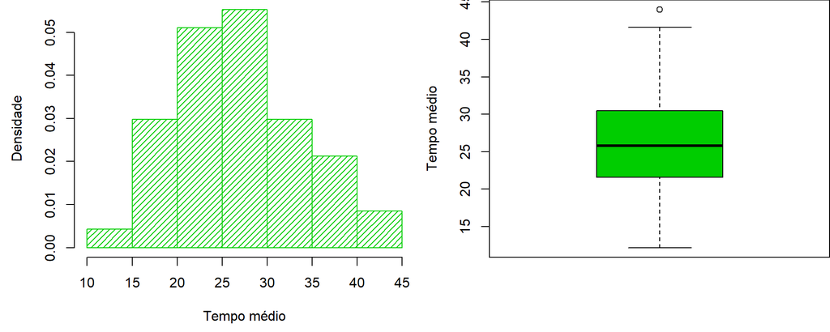

```r
# Histograma ou Boxplot
par(mfrow=c(1,2), mar = c(4.5,4.5,0,0))
hist(UScrime$Time,freq=F,main=" ",xlab = "Tempo médio", ylab = "Densidade",
     col = 3, density = 20)
boxplot(UScrime$Time,ylab = "Tempo médio", col = 3, density = 20)
```

```r
cor(UScrime[c(4,8)])
```

```
##           Po1       Pop
## Po1 1.0000000 0.5262836
## Pop 0.5262836 1.0000000
```

# Questão 7:

Para o banco de dados do pacote MASS, faça uma tabela com a média e o coeficiente de variação para a variável preço máximo separado pelas variáveis nas linhas e nas coulnas.

```r
require(MASS)
require(tables)

data("Cars93")#carregando o banco de dados
head(Cars93)#exibindo as primeiras lihas do banco
```

```
##   Manufacturer   Model    Type Min.Price Price Max.Price MPG.city MPG.highway
## 1        Acura Integra   Small      12.9  15.9      18.8       25          31
## 2        Acura  Legend Midsize      29.2  33.9      38.7       18          25
## 3         Audi      90 Compact      25.9  29.1      32.3       20          26
## 4         Audi     100 Midsize      30.8  37.7      44.6       19          26
## 5          BMW    535i Midsize      23.7  30.0      36.2       22          30
## 6        Buick Century Midsize      14.2  15.7      17.3       22          31
##              AirBags DriveTrain Cylinders EngineSize Horsepower  RPM
## 1               None      Front         4        1.8        140 6300
## 2 Driver & Passenger      Front         6        3.2        200 5500
## 3        Driver only      Front         6        2.8        172 5500
## 4 Driver & Passenger      Front         6        2.8        172 5500
## 5        Driver only       Rear         4        3.5        208 5700
## 6        Driver only      Front         4        2.2        110 5200
##   Rev.per.mile Man.trans.avail Fuel.tank.capacity Passengers Length Wheelbase
## 1         2890             Yes               13.2          5    177       102
## 2         2335             Yes               18.0          5    195       115
## 3         2280             Yes               16.9          5    180       102
## 4         2535             Yes               21.1          6    193       106
## 5         2545             Yes               21.1          4    186       109
## 6         2565              No               16.4          6    189       105
##   Width Turn.circle Rear.seat.room Luggage.room Weight  Origin          Make
## 1    68          37           26.5           11   2705 non-USA Acura Integra
## 2    71          38           30.0           15   3560 non-USA  Acura Legend
## 3    67          37           28.0           14   3375 non-USA       Audi 90
## 4    70          37           31.0           17   3405 non-USA      Audi 100
## 5    69          39           27.0           13   3640 non-USA      BMW 535i
## 6    69          41           28.0           16   2880     USA Buick Century
```

```r
#funcao para calcular cv
cv = function(x){
sd(x)/mean(x)*100
}

#fazendo a tabela:
tabular(AirBags ~ Type*(Max.Price)*Format(digits=2)*(mean + cv), data=Cars93)
```

| AirBags | Type Compact Max.Price mean | Type Compact Max.Price cv | Type Large Max.Price mean | Type Large Max.Price cv | Type Midsize Max.Price mean | Type Midsize Max.Price cv | Type Small Max.Price mean | Type Small Max.Price cv | Type Sporty Max.Price mean | Type Sporty Max.Price cv | Type Van Max.Price mean | Type Van Max.Price cv |
| --- | --- | --- | --- | --- | --- | --- | --- | --- | --- | --- | --- | --- |
| Driver & Passenger | 19.1 | 15.1 | 26.7 | 32.8 | 43.6 | 38.7 | NaN | NA | 20.3 | 15.3 | NaN | NA |
| Driver only | 23.7 | 38.5 | 25.1 | 23.5 | 26.5 | 37.5 | 13.9 | 11.4 | 24.3 | 42.3 | 25.4 | 4.3 |
| None | 15.9 | 27.1 | NaN | NA | 17.6 | 17.8 | 11.3 | 25.1 | 17.4 | 36.6 | 20.3 | 9.3 |